# Data Analysis for Ford GoBike System

## Investigation Overview

The goal of this analysis is to answer the following questions:

- When and where bikes are high in demand (during the day/weekday/month)
- Which type of user use the service most (customer vs subscriber)

## Dataset Overview

Ford GoBike is a regional public bicycle sharing system in the San Francisco Bay Area, California. The company begins operation in August 2013 as Bay Area Bike Share, the Ford GoBike system currently has over 2,600 bicycles in 262 stations across San Francisco, East Bay and San Jose. On June 28, 2017, the system was officially launched as Ford GoBike in a partnership with Ford Motor Company.

In regards to how the system works, it is very similar to other bike share systems. They are bikes that are locked into a network of docking stations throughout the city. The bikes can be unlocked from one station and returned to any other station in the system, making them ideal for one-way trips. These bikes are available for use 24/7 to all members of the system

```python
# import all packages and set plots to be embedded inline
import numpy as np
import pandas as pd
import matplotlib.pyplot as plt
import seaborn as sb
import datetime
%matplotlib inline

# suppress warnings from final output
import warnings
warnings.simplefilter("ignore")
```

```python
# load in the dataset into a pandas dataframe
df_clean = pd.read_csv('clean_master_file.csv')
```

```python
# calculating % split for the user type
customer = df_clean.query('user_type == "Customer"')['bike_id'].count()
subscriber = df_clean.query('user_type == "Subscriber"')['bike_id'].count()

customer_proportion = customer / df_clean['bike_id'].count()
subscriber_proportion = subscriber / df_clean['bike_id'].count()
```

## Number of trips by user type

Ford GoBike System currently offers 3 subscribtion types: Single Ride, Access Pass (24h or 72h) and Monthly Membership. Customers with a monthly membership makes up 87% of the total users in 2019.

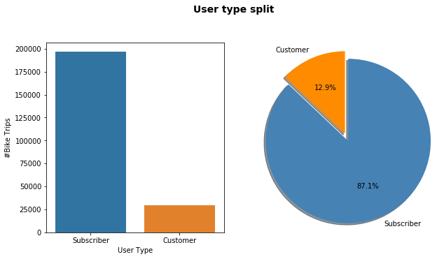

```python
plt.figure(figsize = [10, 5])

# code for the bar chart
plt.subplot(1, 2, 1)

g = sb.countplot(data=df_clean, x="user_type", order=df_clean.user_type.value_counts().index)
g.set_xlabel('User Type')
g.set_ylabel('#Bike Trips')

# code for the pie chart
plt.subplot(1, 2, 2)

labels = ['Customer', 'Subscriber']
sizes = [customer_proportion, subscriber_proportion]
colors = ['darkorange', 'steelblue']
explode = (0, 0.1)

plt.pie(sizes, explode=explode, labels=labels, colors = colors,
        autopct='%1.1f%%', shadow=True, startangle=90)
plt.axis('equal')

plt.suptitle('User type split ', y=1.03, fontsize=14, fontweight='semibold');
```

## Daily and weekly habits by user types

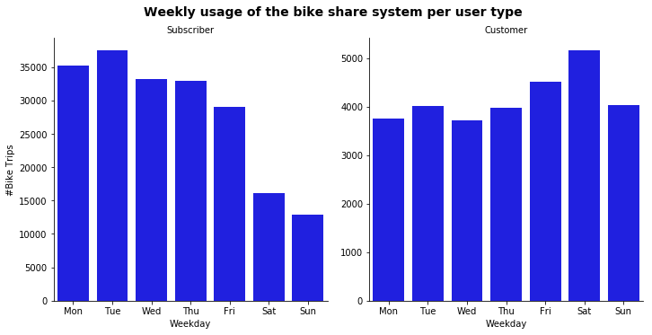

```python
# weekday usage of the bike sharing system per user type

weekday = ['Mon', 'Tue', 'Wed', 'Thu', 'Fri', 'Sat', 'Sun']
g = sb.catplot(data=df_clean, x='start_time_weekday', col="user_type", kind='count', sharey = False,
            color = 'b', order = weekday)
g.set_axis_labels("Weekday", "#Bike Trips")
g.set_titles("{col_name}")
g.fig.suptitle('Weekly usage of the bike share system per user type', y=1.03, fontsize=14, fontweight='semibold');
```

Subscribers appears to use bikes more than customer during weekday. On the other hands, customers seem to use the bike about the same amount throughout the week, including weekend trips

This may be explained that most subscribers use the bikes mainly for daily work/school commute, whereas customers are tourists who do not get affected by the working/school hour, hence the equally usage everday

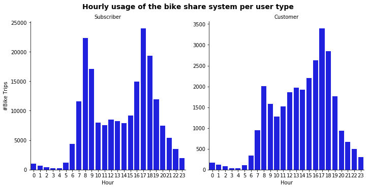

```python
# hourly usage of the bike sharing system per user type

g = sb.catplot(data=df_clean, x='start_time_hour', col="user_type", kind='count', sharey = False,
            color = 'b')
g.set_axis_labels("Hour", "#Bike Trips")
g.set_titles("{col_name}")
g.fig.suptitle('Hourly usage of the bike share system per user type', y=1.03, fontsize=14, fontweight='semibold');
```

Customer use the bike more between 9am to 4pm. This further reinforce our hypothesis that subsribers use it for commuting to work/school since they would not be using it during the work hour

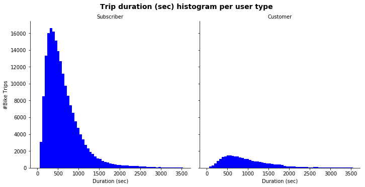

```python
# duration (sec) distribution per user type

g = sb.FacetGrid(df_clean, col="user_type", margin_titles=True, size=5)
bin_edges = np.arange(0, 3600,60)
g.map(plt.hist, "duration_sec", color='b', bins=bin_edges)
g.set_axis_labels("Duration (sec)", "#Bike Trips")
g.set_titles(col_template = '{col_name}')
g.fig.suptitle('Trip duration (sec) histogram per user type', y=1.03, fontsize=14, fontweight='semibold');
```

Subscribers generally has shorter trip duration than customers do

## Bike usage by both user type and gender

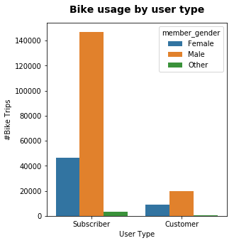

```python
plt.figure(figsize = [10, 5])

plt.subplot(1, 2, 1)

g = sb.countplot(data=df_clean, x="user_type", hue="member_gender", order=df_clean.user_type.value_counts().index)
g.set_xlabel('User Type')
g.set_ylabel('#Bike Trips');
g.set_title('Bike usage by user type', y=1.03, fontsize=14, fontweight='semibold');
```

Overall, it can be seen that males are using the system much more than female. However, the discrepancy between males and females are much greater for subscriber than it is for customer.

[figure not shown]

```python
# weekday usage of the bike sharing system

weekday = ['Mon', 'Tue', 'Wed', 'Thu', 'Fri', 'Sat', 'Sun']
g = sb.catplot(data=df_clean, x='start_time_weekday', col="user_type", hue='member_gender', kind='count', sharey = False,
                order = weekday)
g.set_axis_labels("Weekday", "#Bike Trips")
g._legend.set_title('bike_share_for_all_trip')
g.set_titles("{col_name}")
g.fig.suptitle('Weekly usage of the bike share system per user type and bikeshare', y=1.03, fontsize=14, fontweight='semibold');
```

The trend for both females and males appear to be very similar. Regardless of genders, subscribers tend to use the system more on the weekdays rather than the weekend. And vice versa, customer use the system about the same amount of any day of the week.

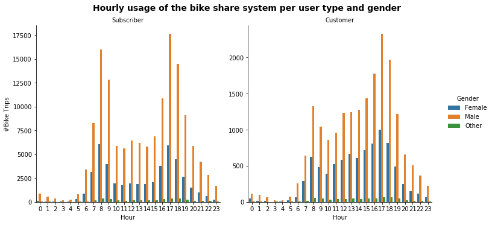

```python
# hourly usage of the bike sharing system per user type and gender

g = sb.catplot(data=df_clean, x='start_time_hour', col="user_type", hue='member_gender', kind='count', sharey = False)
g.set_axis_labels("Hour", "#Bike Trips")
g._legend.set_title('Gender')
g.set_titles("{col_name}")
g.fig.suptitle('Hourly usage of the bike share system per user type and gender', y=1.03, fontsize=14, fontweight='semibold');
```

Again, the pattern for males and females are very similar. This further indicates that gender doesn't affect the demand for bike usage

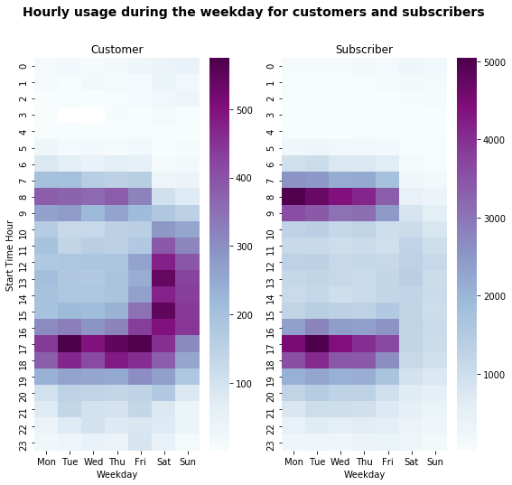

```python
# Setting the weekday order
df_clean['start_time_weekday'] = pd.Categorical(df_clean['start_time_weekday'],
                                                categories=['Mon','Tue','Wed','Thu','Fri','Sat', 'Sun'],
                                                ordered=True)
plt.figure(figsize=(9,8))
plt.suptitle('Hourly usage during the weekday for customers and subscribers', fontsize=14, fontweight='semibold')

# heatmap for customers
plt.subplot(1, 2, 1)
df_customer = df_clean.query('user_type == "Customer"').groupby(["start_time_hour", "start_time_weekday"])["bike_id"].size().reset_index()
df_customer = df_customer.pivot("start_time_hour", "start_time_weekday", "bike_id")
sb.heatmap(df_customer, cmap="BuPu")

plt.title("Customer", y=1.015)
plt.xlabel('Weekday')
plt.ylabel('Start Time Hour')

# heatmap for subscribers
plt.subplot(1, 2, 2)
df_subscriber = df_clean.query('user_type == "Subscriber"').groupby(["start_time_hour", "start_time_weekday"])["bike_id"].size().reset_index()
df_subscriber = df_subscriber.pivot("start_time_hour", "start_time_weekday", "bike_id")
sb.heatmap(df_subscriber, cmap="BuPu")

plt.title("Subscriber", y=1.015)
plt.xlabel('Weekday')
plt.ylabel('');
```

Finally, the heat map summarizes the usage pattern for customer and subscriber. Customers are more clearly active during work hour than subscribers

### Summary

Observation:

### Conclusion:

- Subscribers are likely people who use it for school and work commute, this is supported by the fact that they generally take shorter and quicker trips. Additionally, they have the highest bike usage before 9am and after 5pm, and very low usage between 9am - 5pm, which makes sense as these people do not use the system during work hour
- Customers are likely to be tourists, this is supported by the fact that they take longer trips and the usage is not constrained by day of the week or working hour.
- Male are generally more likely to use and become the member of the system as shown by the male-to-female ratio in terms of number of users and subscriber

```python
!jupyter nbconvert slide_deck_template.ipynb --to slides --post serve --template output_toggle
```